# Class Elicitation Free Production

Michael Lopez-Brau

April 16, 2018

## Updated Results

Manually categorized participant responses and computed their empirical frequencies.

| original_row | degree | supercategory | subcategory | valence | target | adjective_form | phrase | n | mean_frequency | max_frequency | type |
| --- | --- | --- | --- | --- | --- | --- | --- | --- | --- | --- | --- |
| 1 | height | animals | chimpanzee | medium | big | positive | chimpanzees | 9 | 315199 | 378379 | subcategory |
| 3 | height | animals | chimpanzee | medium | big | positive | monkeys | 3 | 4144229 | 4144229 | in between |
| 4 | height | animals | chimpanzee | medium | big | positive | animals | 2 | 58179731 | 58179731 | supercategory |
| 5 | height | animals | chimpanzee | medium | small | negative | chimpanzees | 7 | 317455 | 378379 | subcategory |
| 6 | height | animals | chimpanzee | medium | small | negative | animals | 3 | 58179731 | 58179731 | supercategory |
| 8 | height | animals | chimpanzee | medium | small | negative | monkeys | 2 | 4144229 | 4144229 | in between |
| 9 | height | animals | chimpanzee | medium | small | negative | primates | 1 | 1013017 | 1013017 | in between |
| 10 | height | animals | elephant | high | big | positive | animals | 13 | 58179731 | 58179731 | supercategory |
| 11 | height | animals | elephant | high | big | positive | elephants | 3 | 2082778 | 2082778 | subcategory |
| 12 | height | animals | elephant | high | big | positive | vegetables | 1 | 9067552 | 9067552 | not relevant |
| 13 | height | animals | elephant | high | small | negative | elephants | 9 | 2531023 | 6116985 | subcategory |
| 15 | height | animals | elephant | high | small | negative | giraffes | 1 | 260416 | 260416 | different subcategory |
| 16 | height | animals | porcupine | low | big | positive | porcupines | 9 | 86556 | 86556 | subcategory |
| 17 | height | animals | porcupine | low | big | positive | animals | 5 | 58179731 | 58179731 | supercategory |
| 18 | height | animals | porcupine | low | big | positive | critters | 1 | 1055985 | 1055985 | in between |
| 19 | height | animals | porcupine | low | small | negative | porcupines | 7 | 86556 | 86556 | subcategory |
| 20 | height | animals | porcupine | low | small | negative | animals | 5 | 58179731 | 58179731 | supercategory |
| 21 | temperature | beverages | cup of coffee | high | cold | negative | coffee | 6 | 14112760 | 42090859 | subcategory |
| 22 | temperature | beverages | cup of coffee | high | cold | negative | drinks | 3 | 11137329 | 11137329 | supercategory synonym |
| 24 | temperature | beverages | cup of coffee | high | cold | negative | hot beverages | 1 | 45128 | 45128 | in between |
| 25 | temperature | beverages | cup of coffee | high | cold | negative | warm coffee | 1 | 4745 | 4745 | in between |
| 26 | temperature | beverages | cup of coffee | high | cold | negative | warm drinks | 1 | 8480 | 8480 | in between |
| 27 | temperature | beverages | cup of coffee | high | warm | positive | drinks | 7 | 11137329 | 11137329 | supercategory synonym |
| 28 | temperature | beverages | cup of coffee | high | warm | positive | coffee | 5 | 8517141 | 42090859 | subcategory |
| 29 | temperature | beverages | cup of coffee | high | warm | positive | beverages | 3 | 123711 | 123711 | supercategory |
| 31 | temperature | beverages | cup of iced tea | low | cold | negative | drinks | 6 | 11137329 | 11137329 | supercategory synonym |
| 32 | temperature | beverages | cup of iced tea | low | cold | negative | tea | 3 | 18293438 | 27413229 | in between |
| 33 | temperature | beverages | cup of iced tea | low | cold | negative | iced tea | 3 | 139086 | 393524 | subcategory |
| 37 | temperature | beverages | cup of iced tea | low | warm | positive | beverages | 3 | 6337606 | 6337606 | supercategory |
| 38 | temperature | beverages | cup of iced tea | low | warm | positive | tea | 3 | 9173468 | 27413229 | in between |

[output cut: 222 more lines]

## Summary

In addition to the points brought up at the bottom of class-elicitation-freeProduction-2.Rmd:

- There’s a lot of variability in the degree of specifity for the comparison class for the subcategory “days in Fall”. This creates two issues:
  1. Is “days” supposed to mean days of the year or a more specific window of time?
  2. How should we extract frequencies for “fall” due to polysemy? To merge it with other, more specific terms, we need to answer the first question.
- Participants never included “flower” in their response to the questions on flower vases.
- Some participants interpreted “wardrobe” to mean clothing.
- Routes is tricky because of the colloquial usage of “drives” and “trips”; do we collapse “drives” with “trips” or with “driving routes”?

## Unique Responses

Plotted the number of unique responses (y-axis) by subcategory (x-axis) plotted for each item in “target”.

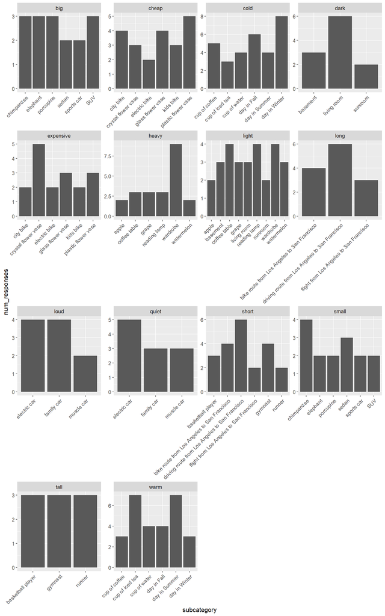

### Number of unique responses

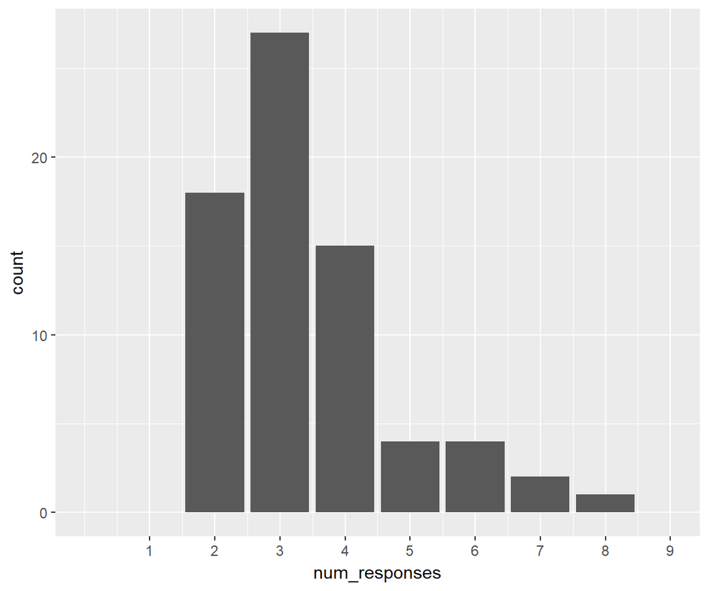

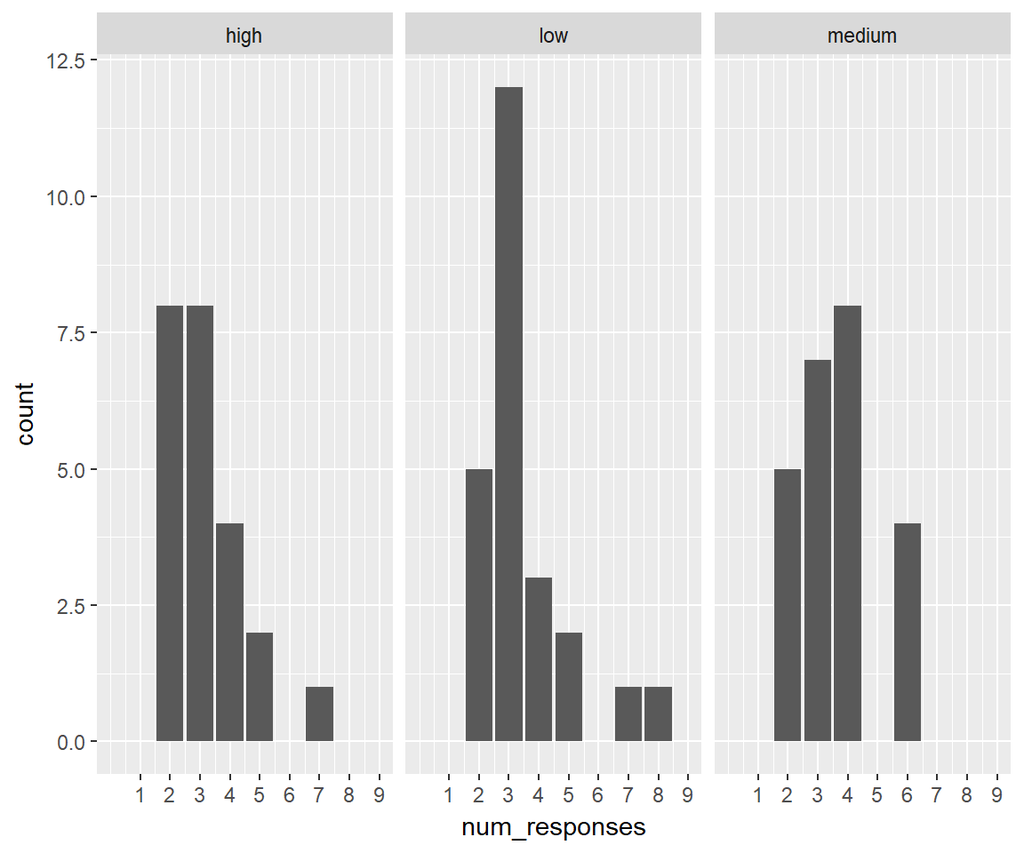

#### Number of unique responses that are produced by more than 1 person

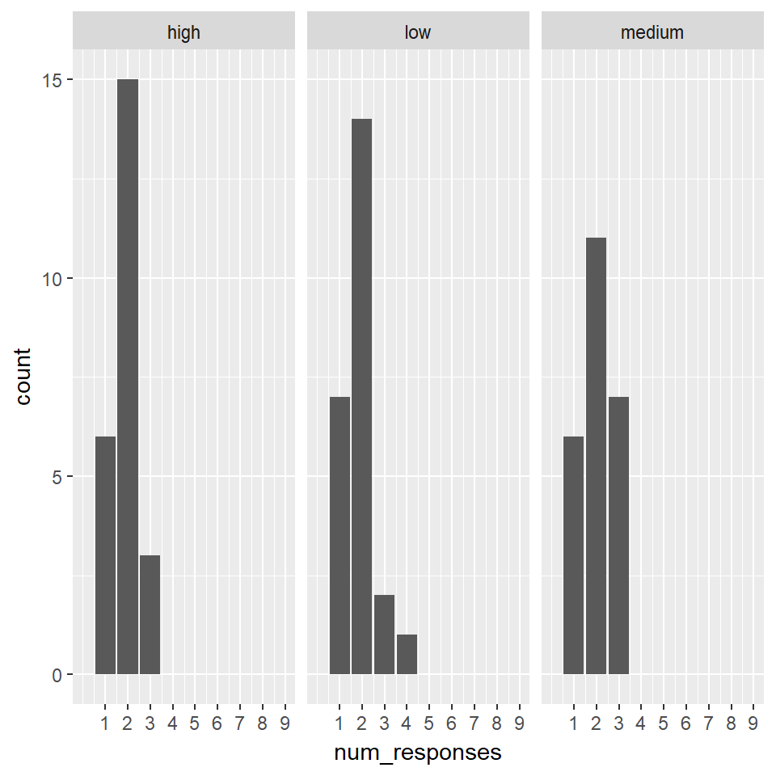

Looks like medium items might get more classes? Maybe pre-register as an exploratory analysis…In more open-ended contexts, there is more ambiguity about what th comparison class is. What our manipulations are doing is providing information (world knowledge + adjective used) to narrow in on particular classes.

To add: - Code adjectives as either positive or negative. - Code sub_categories as either low, medium, or high (can be taken directly from the adjective-elicitation task, …)

## Change Log

### Cleaned

- Row 115 from “days fall” to “days in Fall”
- Row 116 from “fall” to “days in Fall”
- Row 117 from “fall days maryland” to “days in Fall in Maryland”
- Row 119 from “seasons maryland” to “seasons in Maryland”
- Row 121 from “days fall” to “days in Fall”
- Row 124 from “fall seasons” to “Falls”
- Row 126 from “summer days” to “days in Summer”
- Row 127 from “days summer” to “days in Summer”
- Row 128 from “summer days maryland” to “days in Summer in Maryland”
- Row 134 from “summer days” to “days in Summer”
- Row 144 from “winter days maryland” to “days in Winter in Maryland”
- Row 146 from “winter days” to “days in Winter”
- Row 147 from “days winter” to “days in Winter”
- Row 182 from “objets” to “objects”
- Row 245 from “house” to “houses”
- Row 248 from “times day” to “times of day”
- Row 249 from “living” to “living rooms”
- Row 252 from “house” to “houses”
- Row 254 from “times day” to “times of day”
- Row 255 from “house” to “houses”
- Row 256 from “living” to “living rooms”
- Row 257 from “middle day” to “middle of the days” or “midday”
- Row 259 from “times day” to “times of day”
- Row 261 from “time day” to “times of day”

### Collapsed

- Rows 1 (chimpanzees) and 2 (chimps)
- Rows 5 (chimpanzees) and 7 (chimps)
- Rows 13 (elephants) and 14 (elephant)
- Rows 21 (cups coffee) and 23 (coffee)
- Rows 28 (cups coffee) and 30 (coffee)
- Rows 32 (tea) and 34 (cups tea)
- Rows 33 (cups iced tea), 35 (iced tea), and 36 (iced teas)
- Rows 38 (cups tea) and 47 (tea)
- Rows 41 (cups iced tea), 43 (ice teas), 45 (iced tea), and 46 (iced teas)
- Rows 50 (water) and 52 (cups water)
- Rows 53 (cups water) and 54 (water)
- Rows 71 (kids bikes) and 73 (kid bikes)
- Rows 92 (muscle cars) and 95 (hot rod cars)
- Rows 104 (sports cars) and 105 (sport cars)
- Rows 107 (suvs) and 109 (suv)
- Rows 110 (suvs) and 112 (sus)
- Rows 115 (days fall) and 116 (fall)
- Rows 121 (days fall) and 122 (fall days)
- Rows 146 (winter days) and 147 (days winter)
- Rows 152 (vases) and 157 (vaes)
- Rows 171 (plastic vases) and 173 (vases plastic)
- Rows 176 (apples) and 178 (apple)
- Rows 180 (fruit) and 181 (fruits)
- Rows 184 (fruit) and 185 (fruits)
- Rows 187 (watermelons) and 189 (watermelon)
- Rows 190 (watermelons), 194 (watermellons), and 195 (watermelon)
- Rows 191 (fruit) and 192 (fruits)
- Rows 227 (people) and 229 (humans)
- Rows 231 (gymnasts) and 233 (gymnast)
- Rows 267 (bike routes) and 268 (bike route)
- Rows 286 (flights) and 287 (flightws)